# Yelp Ambience Marketing Study

Phil Burdi  
Sat Nov 21 09:53:13 2015

**Class Presentation for final capstone project (Signature Track Class10)**

### What is Yelp Ambience data and Why is it important?

- Ambience is a business attribute located in the Yelp business data and represents the “ambience” of a particular establishment based on the reviews or tips provided by a client or user of this establishment.
- It is important as a marketing tool for use by Yelp and their business partners to focus promotions or gather data on specific categories of establishments that produce an “ambience” type.
- Yelp contains many categories from Hotels to Heating, from Auto Repair to Human Repair, etc. each of these categories may have “ambience”“ data associated with the establishment.

### How does the Ambience Marketing Study Help?

- Combining the Business Category and Ambience attributes help you identify your target clients!
- The methods used in the data analysis include a drill down on the businesses with “ambience” data and extracting the user/client base from one ambience example, “trendy” food establishments. The analysis will look at the reviewers and tip posers to determine if a correlation exists with attributes of those users.
- The current “ambience” attributes in the Yelp data are:

```
[1] "romantic" "intimate" "classy"   "hipster"  "divey"    "touristy"
[7] "trendy"   "upscale"  "casual"
```

### Another Benefit: Attracting Followers!

*People who fill in data on the Ambience bring in followers!*

After reviewing the study, you should be convinced:

- Ambience Reviewers rock with other people and have a larger overall Fan base!
- Ambience Tip Posters are popular and more likely to post reviews!
- Targeting Fans of these Reviewers and Tip Posters has potential!

### "Look at the Data!"

Ambience Reviewers and Tip Posters with their Fans!

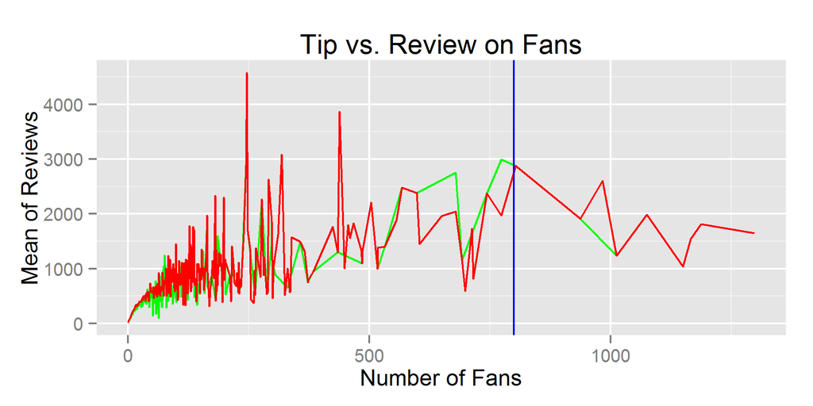

*Actual Data from the Yelp Ambience Marketing Study*